# Ch. 3

ECON 3406

Dr. Josh Martin

## Intro to probability

- The **probability** of an outcome is the proportion of times the outcome would occur if we observed the random process an infinite number of times
  - Probability is defined as a **proportion**, and it always takes values between 0 and 1 (or displayed as a percentage)

## Law of large numbers

- Example: rolling a die many times
  - Let $\hat{p}_n$ be the proportion of outcomes that are 1 after the first $n$ rolls
  - As the number of rolls increases, $\hat{p}_n$ will converge to the probability of rolling a 1, $p = \frac{1}{6}$
- The tendency of $\hat{p}_n$ to stabilize around $p$ is described by the **Law of Large Numbers**

## Law of large numbers

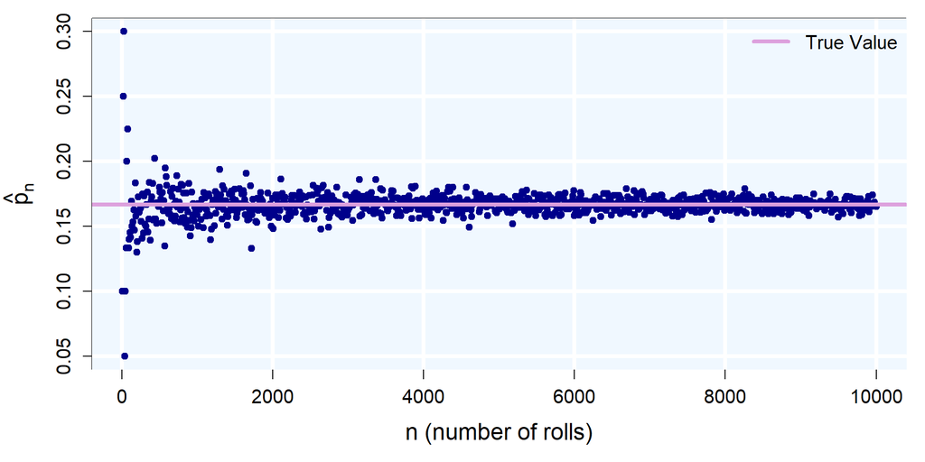

## Law of large numbers

- LLN: As more observations are collected, the proportion $\hat{p}_n$ of occurrences with a particular outcome converges to the probability $p$ of that outcome
- Occasionally the proportion will veer off from the probability and appear to “defy” the Law of Large Numbers
  - However, these deviations become smaller as the number of rolls increases

## Disjoint (or mutually exclusive) outcomes

- Two outcomes are called disjoint (or mutually exclusive) if they cannot both happen
- For instance, if we roll a die, the outcomes 1 and 2 are disjoint since they cannot both occur
- On the other hand, the outcomes 1 and “rolling an odd number” are not disjoint since both occur if the outcome of the roll is a 1
- Calculating the probability of disjoint outcomes is easy – add their separate probabilities

$$P(\text{1 or 2}) = \dfrac{1}{6} + \dfrac{1}{6} = \dfrac{2}{6} = \dfrac{1}{3}$$

## Addition Rule of Disjoint Outcomes

- If there are many disjoint outcomes $A_1, ..., A_k$, then the probability that one of these outcomes will occur is:

$$P(A_1) + P(A_2) + · · · + P(A_k)$$

## Disjoint outcomes

- Data scientists rarely work with individual outcomes and instead consider **sets** or **collections of outcomes**
- Let **A** represent the event where a die roll results in 1 or 2 and **B** represent the event that the die roll is a 4 or a 6
  - A = {1, 2}; B = {4, 6}
  - These sets are commonly called events
- Because A and B have no elements in common, they are disjoint events

$$P(\text{A or B}) = P(A) + P(B) = \dfrac{2}{6} + \dfrac{2}{6} = \dfrac{4}{6} = \dfrac{2}{3}$$

## Reminder on card decks

- The 52 cards are split into four suits: club, diamond, heart, spade
  - Each suit has its 13 cards labeled: 2, 3, …, 10, jack, queen, king, and ace
  - Thus, each card is a unique combination of a suit and a label
  - The 12 cards represented by the jacks, queens, and kings are called face cards
  - The cards that are diamond and heart are typically colored red while the other two suits are typically colored black

## Probabilities when events are not disjoint

- What is the probability that a randomly selected card is a diamond?
  - $P(♢) = \dfrac{13}{52} = \dfrac{1}{4} = 0.25$
- What is the probability that a randomly selected card is a face card?
  - $P(\text{face}) = \dfrac{12}{52} \approx 0.23$
- What is the probability that a randomly selected card is a face card or a diamond?
  - $P(\text{face or ♢}) = P(\text{face}) + P(♢) - P(\text{face and ♢})$
  - $P(\text{face or ♢}) = \dfrac{13}{52} + \dfrac{12}{52} - \dfrac{3}{52} = \dfrac{22}{52} \approx 0.42$

## General Addition Rule

- If A and B are any two events, disjoint or not, then the probability that at least one of them will occur is:

$$P(\text{A or B}) = P(A) + P(B) − P(\text{A and B})$$

- where $P(\text{A and B})$ is the probability that both events occur
- If A and B are disjoint, this implies $P(\text{A and B}) = 0$

## Probability distribution

- A probability distribution is a representation of all disjoint outcomes and their associated probabilities
  - The outcomes listed must be disjoint
  - The probabilities must total 1

## Probability distribution

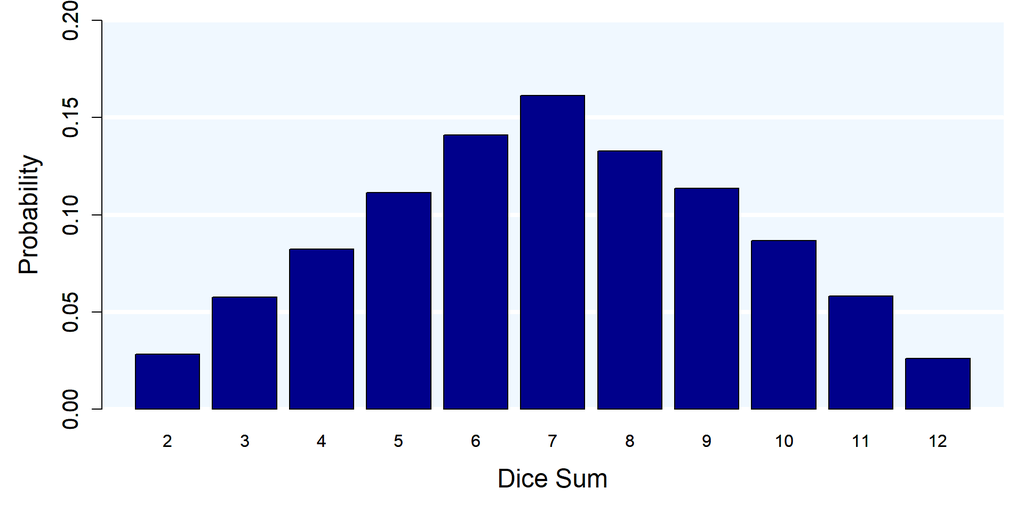

## Independence

- Two processes are **independent** if knowing the outcome of one provides no useful information about the outcome of the other
  - For instance, flipping a coin and rolling a die are two independent processes – knowing the coin was heads does not help determine the outcome of a die roll
  - On the other hand, stock prices usually move up or down together, so they are not independent

## Multiplication rule for independent processes

- If $A$ and $B$ represent events from two different and independent processes, then the probability that both $A$ and $B$ occur can be calculated as the product of their separate probabilities:

$$P(\text{A and B}) = P(A) \times P(B)$$

- Similarly, if there are $k$ events $A_1, ..., A_k$ from $k$ independent processes, then the probability they all occur is:

$$P(A_1) \times P(A_2) \times \text{...} \times P(Ak)$$

## Multiplication rule for independent processes

- If we roll two dice, what is the probability that you roll two 1s?

$$P(\text{1 and 1}) = \dfrac{1}{6} \times \dfrac{1}{6} = \dfrac{1}{36}$$

- 1/6th of the first rolls are a 1 and 1/6th of those times where the first roll is a 1 the second roll is also a 1

## Multiplication rule for independent processes

```r
set.seed(1)
x <- data.frame(
  dice1 = sample(1:6, 10000, replace = TRUE),
  dice2 = sample(1:6, 10000, replace = TRUE)
)

x$ones <- ifelse(x$dice1 == 1 & x$dice2 == 1, 1, 0)
mean(x$ones)
```

```
[1] 0.0283
```

```r
1/36
```

```
[1] 0.02777778
```

```r
nrow(x)
```

```
[1] 10000
```